# HW10 - Data Analysis

WDI

93111399

2018-07-15 09:29:56

# Qestion 1:

We will first install the necessary package and include the libraries:

```r
#First we will install the package:
#install.packages("WDI")

#-----------------------------
# Our Necessary Libraries:
library("WDI")
library("dplyr")
library("ggplot2")
library("highcharter")
library("ggthemes")
library("cluster")
library("fpc")
```

Now we will use `WDI` data to find the poorest countries. We will consider year 2010 because it hase the most data the main indicator is `SI.POV.GAPS`.

```r
#-----------------------------
#Important Indicators:
data = WDI(indicator = c("NY.GDP.PCAP.PP.CD",
                             "SI.POV.GAPS",
                             "SP.DYN.LE00.IN"),extra = TRUE,
               start = 1960, end = 2018)
data_check <- subset(data, region != "Aggregates")

#-----------------------------
#We will use the year with the most data. which is 2010
data_check %>% filter(year == 2010) %>% arrange(desc(SI.POV.GAPS)) -> Poor

Poorest <- Poor[1:10,"country"]
Poorest_data <- Poor[1:10,]
Poorest %>% print()
```

```
##  [1] "Madagascar"            "Malawi"
##  [3] "Lesotho"               "Zambia"
##  [5] "Guinea-Bissau"         "Rwanda"
##  [7] "Ethiopia"              "Sao Tome and Principe"
##  [9] "Gambia, The"           "Macedonia, FYR"
```

```r
#-----------------------------
#Ploting with hchart:
Poorest_data %>% hchart(type = "column", hcaes(x = country, y = NY.GDP.PCAP.PP.CD/365)) %>%
  hc_title(text = 'PPP of the top 10 poorest countries in 2010') %>%
  hc_xAxis(title = list(text = 'Country')) %>%
  hc_yAxis(title = list(text = 'USD'))
```

[interactive chart not shown]

```r
#-----------------------------
# Life span:
Poorest_data %>% select(country, SP.DYN.LE00.IN) %>% print()
```

```
##                  country SP.DYN.LE00.IN
## 1             Madagascar         63.388
## 2                 Malawi         57.263
## 3                Lesotho         50.826
## 4                 Zambia         56.588
## 5          Guinea-Bissau         55.050
## 6                 Rwanda         63.140
## 7               Ethiopia         61.625
## 8  Sao Tome and Principe         65.875
## 9            Gambia, The         59.622
## 10        Macedonia, FYR         74.632
```

# Question 2:

In the Rwanda tragedy more than one million people have died. We will first plot the box plot and then add the line plot. We can see that the tragedy is visible.

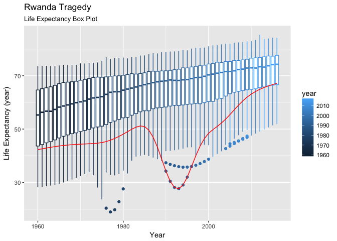

```r
#-----------------------------
LE <- subset(data, region != "Aggregates") %>%
  select(country = country , year = year , LE = SP.DYN.LE00.IN)

LE %>% filter(country =="Rwanda") %>%
  group_by(year) %>%
  summarise( LE  = mean( LE )) %>% na.omit() ->Rwanda


plot = ggplot(data =LE) + geom_boxplot(aes( y = LE , x= year , group = year , color = year)) +
  geom_line(data = Rwanda , aes(x = year, y =  LE), color = "red") +
  ggtitle("Rwanda Tragedy", "Life Expectancy Box Plot") +
  xlab("Year") +
  ylab("Life Expectancy (year)")
plot
```

```r
#-----------------------------
```

# Question 3:

We will make the Life Expectancy-Health Expenditure plot which is as follows:  
Changing the health expenditure can make drastic changes in the life expectancy.

```r
data_health = WDI(indicator = c("SH.XPD.CHEX.PC.CD", "SP.DYN.LE00.IN"),
             extra = TRUE, start = 1960, end = 2018)
subset(data_health ,  region != "Aggregates" ) %>% na.omit() -> health

health %>% select( LE = SP.DYN.LE00.IN, HE = SH.XPD.CHEX.PC.CD, year = year) -> health_new

health_new %>% hchart("scatter" , hcaes(x = HE , y = LE , group = year)) %>%
  hc_xAxis(title = list(text = 'Health expenditure')) %>%
  hc_yAxis(title = list(text = 'Life Expectancy')) %>%
  hc_title(text = 'Health expenditure per capita - Life Expectancy')
```

[interactive chart not shown]

# Question 4:

We can see from the plot below that it has increased in time.

```r
#data frame for ppp:
money <- data %>% filter(country == "Iran, Islamic Rep.") %>%
                  select(money = "NY.GDP.PCAP.PP.CD" , year = year ) %>%
                  arrange(year) %>%
                  na.omit()
# ploting:
money %>% hchart(type ="scatter", hcaes(x = year, y =money ), color = "black") %>%
                   hc_title(text = "PPP of Iran") %>%
                   hc_xAxis(title = list(text = 'Year')) %>%
                   hc_yAxis(title = list(text = 'USD'))
```

[interactive chart not shown]

# Question 5: We will first take the 20 indicators then we will make a plot for every year.  
We can see that for `Exports ad a Capacity to Import` of Iran is much more than of the world. For many of the indicators we can see Iran is clearly close to the world. For `Net Taxes` we are much less than the world and there’s a clease gap between Iran and world in `Oil rents`.

```r
indicators = c("NY.EXP.CAPM.KN", "NY.GDP.DEFL.KD.ZG", "NY.GDP.FCST.CD","NY.TRF.NCTR.CD", "NY.TAX.NIND.CD", "NY.GSR.NFCY.CD",
               "NY.GNS.ICTR.ZS", "NY.GNP.PCAP.PP.CD", "NY.GDP.PCAP.PP.CD","NY.GNP.PCAP.KD", "NY.GNP.PCAP.KD.ZG", "NY.GDP.PCAP.KD.ZG",
               "NY.ADJ.NNTY.CD", "NY.GDP.COAL.RT.ZS", "NY.GDP.FRST.RT.ZS", "NY.GDP.MINR.RT.ZS", "NY.GDP.PETR.RT.ZS", "NY.GNP.ATLS.CD",
               "NY.GDP.NGAS.RT.ZS", "NY.GDP.TOTL.RT.ZS")

wdi_cache <- WDIcache()

parameters = WDI(indicator = indicators, extra = TRUE, start = 1990, end = 2018)

Iran <- subset(parameters, region != "Aggregates") %>% filter(country == "Iran, Islamic Rep.") %>% arrange(year)

world = data.frame()
for (i in 1990:2017) {
  subset(parameters, region != "Aggregates") %>% filter(country != "Iran, Islamic Rep.") %>% select(year, 4:23) %>%
    filter(year == i) %>% colMeans(na.rm = TRUE) -> check
  rbind(world, check) -> world
}
colnames(world) = c("year", indicators)
chart_plot = list()
i = 1
for (indicator in indicators)
{
  plot_ir <- Iran %>% select( year,z= indicator) %>% mutate(place = "Iran")
  plot_world <- world %>% select(year, z=indicator) %>% mutate(place = "world")

  ir_world = rbind(plot_ir,plot_world) %>% na.omit()
  hc <- ir_world %>% hchart(type = "column", hcaes(x = year, y = z, group = place)) %>%
    hc_xAxis(title = list(text = 'Year')) %>%
    hc_yAxis(title = list(text = 'Indicators Value')) %>%
    hc_title(text = as.character(wdi_cache$series[which(
                 wdi_cache$series[,1] == indicator),2]),margin = 20, align = "center",
           style = list(useHTML = TRUE))
  chart_plot[[i]] = hc
  i = i+1

}
htmltools::tagList(chart_plot)
```

[interactive chart not shown]

# Question 6:

We will find the Iran cluster using `k-means` algorithm.

```r
parameters_new = WDI(indicator = indicators, extra = TRUE, start = 1998, end = 2017)
parameters_new <- subset(parameters_new, region != "Aggregates")

parameters_new %>% group_by(country) %>% select(country, 4:23) %>%
  summarise_all(funs(mean, "mean", mean(., na.rm = TRUE))) %>% na.omit() ->
  k_means_data

scale(k_means_data %>% select(-country)) -> scale
kmeans(scale, centers = 3) -> data.cluster
data.cluster$cluster[which(k_means_data$country == "Iran, Islamic Rep.")] ->
  cluster.iran
print(cat(k_means_data$country[which(data.cluster$cluster == cluster.iran)]))
```

```
## Algeria Azerbaijan Congo, Dem. Rep. Gabon Indonesia Iran, Islamic Rep. Kazakhstan Liberia Mauritania Mongolia Nigeria Oman Papua New Guinea Russian Federation Timor-Leste Venezuela, RB Vietnam Yemen, Rep.NULL
```

# Question 7:

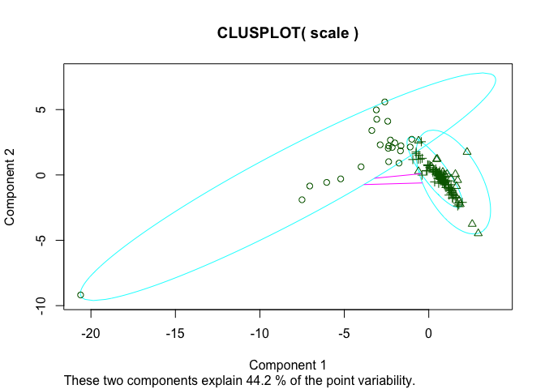

```r
library(cluster)
library(fpc)

clusplot(scale, data.cluster$cluster) # this will plot the first two components
```

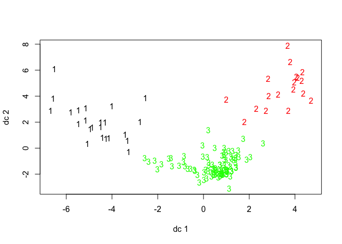

```r
plotcluster(scale, data.cluster$cluster) # checking the performance as a graph
```

# Question 8:

Using `Linear Regression Model` using some of the indicators can be a way to predict to following years. These kinds of predictions are usually called type 2 chaiotic predictions. Type 2 chaiotic predictions are predicting things which the prediction itself can influence the outcome, this is in contrast with type 1 chaiotic systems which the prediction doesn’t affect the outcome. Predicting such variables are indeed type 2 chaiotic predictions.

# Question 9:

We will do the same process we had as follows:

```r
#-----------------------------
# Health:
indicators_health = c("SH.XPD.CHEX.GD.ZS", "SH.XPD.CHEX.PC.CD", "SH.XPD.CHEX.PP.CD","SH.XPD.GHED.CH.ZS", "SH.XPD.GHED.GD.ZS", "SH.XPD.GHED.GE.ZS",
                      "SH.XPD.GHED.PC.CD", "SH.XPD.PVTD.CH.ZS", "SH.XPD.PVTD.PC.CD","SH.IMM.IDPT", "SH.MMR.RISK.ZS", "SH.DYN.MORT",
                      "SH.H2O.SMDW.ZS", "SH.XPD.OOPC.CH.ZS", "SH.XPD.OOPC.PC.CD", "SH.VAC.TTNS.ZS", "SP.DYN.LE00.IN", "SH.DYN.AIDS.FE.ZS",
                      "SH.IMM.MEAS", "SH.IMM.HEPB")

parameters_health = WDI(indicator = indicators_health, extra = TRUE, start = 1998, end = 2018)

Iran <- subset(parameters_health, region != "Aggregates") %>% filter(country == "Iran, Islamic Rep.") %>% arrange(year)

#-----------------------------
world = data.frame()
for (i in 1998:2017) {
  subset(parameters_health, region != "Aggregates") %>% filter(country != "Iran, Islamic Rep.") %>% select(year, 4:23) %>%
    filter(year == i) %>% colMeans(na.rm = TRUE) -> check
  rbind(world, check) -> world
}
colnames(world) = c("year", indicators_health)

chart_plot_9 = list()
i = 1
for (indicator in indicators_health)
{
  plot_ir <- Iran %>% select( year,z= indicator) %>% mutate(place = "Iran")
  plot_world <- world %>% select(year, z=indicator) %>% mutate(place = "world")

  ir_world = rbind(plot_ir,plot_world) %>% na.omit()
  hc <- ir_world %>% hchart(type = "column", hcaes(x = year, y = z, group = place)) %>%
    hc_xAxis(title = list(text = 'Year')) %>%
    hc_yAxis(title = list(text = 'Indicators Value')) %>%
    hc_title(text = as.character(wdi_cache$series[which(
                 wdi_cache$series[,1] == indicator),2]),margin = 20, align = "center",
           style = list(useHTML = TRUE))
  chart_plot_9[[i]] = hc
  i = i+1

}
htmltools::tagList(chart_plot_9)
```

[interactive chart not shown]

```r
#-----------------------------
#Clustering:
parameters_new <- subset(parameters_health, region != "Aggregates")

parameters_new %>% group_by(country) %>% select(country, 4:23) %>%
  summarise_all(funs(mean, "mean", mean(., na.rm = TRUE))) %>% na.omit() ->
  k_means_data_health

scale(k_means_data_health %>% select(-country)) -> scale_health
kmeans(scale_health, centers = 3) -> data.cluster_health
data.cluster_health$cluster[which(k_means_data_health$country == "Iran, Islamic Rep.")] ->
  cluster.iran_health
print(cat(k_means_data_health$country[which(data.cluster_health$cluster == cluster.iran_health)]))
```

```
## Albania Colombia Ecuador Guatemala Iran, Islamic Rep. Jordan Malaysia Mexico Morocco Nicaragua Peru TunisiaNULL
```

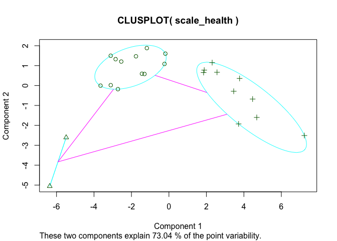

```r
#-----------------------------
#PCA:

clusplot(scale_health, data.cluster_health$cluster) # this will plot the first two components
```

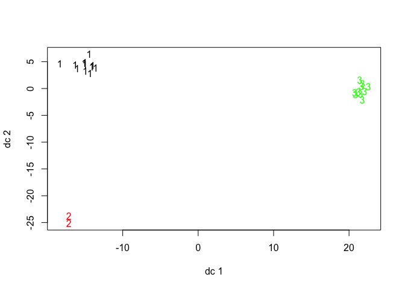

```r
plotcluster(scale_health, data.cluster_health$cluster) # checking the performance as a graph
```

```r
#-----------------------------
```

```r
#Education:
indicators_edu = c("SE.ADT.1524.LT.ZS", "SE.ADT.LITR.ZS", "SE.ENR.PRIM.FM.ZS",
  "SE.ENR.PRSC.FM.ZS", "SE.ENR.SECO.FM.ZS", "SE.ENR.TERT.FM.ZS",
  "SE.PRE.ENRL.TC.ZS", "SE.PRM.TCAQ.ZS", "SE.XPD.TOTL.GB.ZS",
  "SE.XPD.MTOT.ZS", "SE.XPD.CTOT.ZS", "SE.TER.CUAT.BA.ZS",
  "SE.TER.CUAT.DO.ZS", "SE.TER.CUAT.MS.ZS", "SE.TER.CUAT.ST.ZS",
  "SE.SEC.DURS", "SE.PRM.TENR", "SE.PRM.REPT.ZS",
  "SE.PRM.OENR.ZS", "SE.PRM.GINT.ZS")

parameters_edu = WDI(indicator = indicators_edu, extra = TRUE, start = 1998, end = 2017)

Iran <- subset(parameters_edu, region != "Aggregates") %>% filter(country == "Iran, Islamic Rep.") %>% arrange(year)

#-----------------------------
world = data.frame()
for (i in 1998:2017) {
  subset(parameters_edu, region != "Aggregates") %>% filter(country != "Iran, Islamic Rep.") %>% select(year, 4:23) %>%
    filter(year == i) %>% colMeans(na.rm = TRUE) -> check
  rbind(world, check) -> world
}
colnames(world) = c("year", indicators_edu)

chart_plot_10 = list()
i = 1
for (indicator in indicators_edu)
{
  plot_ir <- Iran %>% select( year,z= indicator) %>% mutate(place = "Iran")
  plot_world <- world %>% select(year, z=indicator) %>% mutate(place = "world")

  ir_world = rbind(plot_ir,plot_world) %>% na.omit()
  hc <- ir_world %>% hchart(type = "column", hcaes(x = year, y = z, group = place)) %>%
    hc_xAxis(title = list(text = 'Year')) %>%
    hc_yAxis(title = list(text = 'Indicators Value')) %>%
    hc_title(text = as.character(wdi_cache$series[which(
                 wdi_cache$series[,1] == indicator),2]),margin = 20, align = "center",
           style = list(useHTML = TRUE))
  chart_plot_10[[i]] = hc
  i = i+1

}
htmltools::tagList(chart_plot_10)
```

[interactive chart not shown]

```r
#-----------------------------
#Clustering:
parameters_new <- subset(parameters_edu, region != "Aggregates")

parameters_new %>% group_by(country) %>% select(country, 4:23) %>%
  summarise_all(funs(mean, "mean", mean(., na.rm = TRUE))) %>% na.omit() ->
  k_means_data_edu

scale(k_means_data_edu %>% select(-country)) -> scale_edu
kmeans(scale_edu, centers = 3) -> data.cluster_edu
data.cluster_edu$cluster[which(k_means_data_edu$country == "Iran, Islamic Rep.")] ->
  cluster.iran_edu
print(cat(k_means_data_edu$country[which(data.cluster_edu$cluster == cluster.iran_edu)]))
```

```
## Iran, Islamic Rep. Kuwait Kyrgyz Republic Moldova Mongolia Puerto Rico SerbiaNULL
```

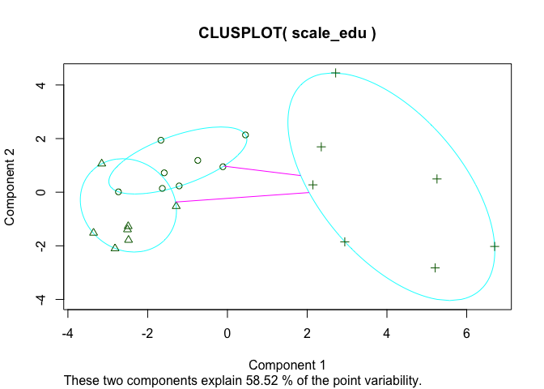

```r
#-----------------------------
#PCA:

clusplot(scale_edu, data.cluster_edu$cluster) # this will plot the first two components
```

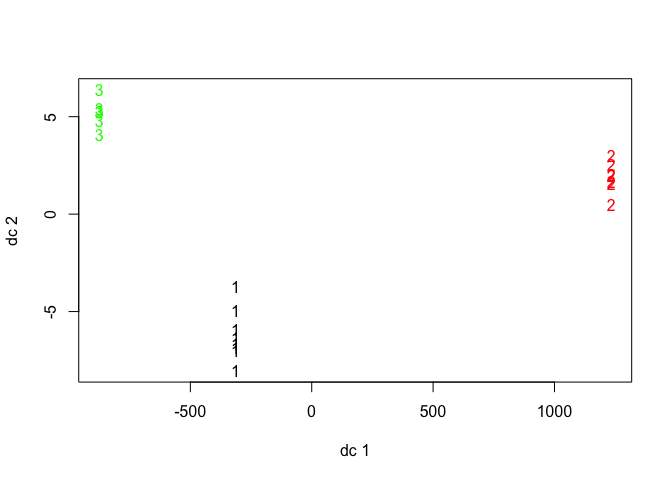

```r
plotcluster(scale_edu, data.cluster_edu$cluster) # checking the performance as a graph
```

# Question 10:

```r
merged = merge(k_means_data,merge(k_means_data_health,k_means_data_edu)) %>% select(-country)
dist = stats::dist(merged_c,method = "euclidean")
row.names(dist) = merged$country
clus = hclust(dist, method = "complete")
```

# Question 11:

1. How has the labor force in Middle east and North Africa changed?

```r
labor =WDI(indicator= c("SL.TLF.TOTL.MA.ZS"),
          extra = TRUE, start = 1998, end = 2017)
labor <- subset(labor, region = "Middle East & North Africa")

labor %>%    select(country ,year, percent ="SL.TLF.TOTL.MA.ZS") %>% arrange(year)  -> labor_temp
labor_temp %>% hchart(type = "line",
                     hcaes(x = year, y = percent, group = country))  %>%
  hc_title(text = "Labor Force in Time for Middle east and North Africa countries",
           align = 'center') %>%
  hc_xAxis(title = list(text = 'Year')) %>%
  hc_yAxis(title = list(text = 'Labor Force(%)'))
```

[interactive chart not shown]

2. How is the the number of teachers correlated to the number of educated people?

```r
labor =WDI(indicator= c("SE.TER.ENRL", "SE.TER.TCHR"),
          extra = TRUE, start = 1998, end = 2017)
labor  %>% select(number_teachers ="SE.TER.TCHR", educated ="SE.TER.ENRL") %>% na.omit()-> labor_temp

t.test(labor_temp$number_teachers,labor_temp$educated)
```

```
##
##  Welch Two Sample t-test
##
## data:  labor_temp$number_teachers and labor_temp$educated
## t = -14.918, df = 2212.3, p-value < 2.2e-16
## alternative hypothesis: true difference in means is not equal to 0
## 95 percent confidence interval:
##  -7864393 -6036982
## sample estimates:
## mean of x mean of y
##    461280   7411968
```

3. Which 10 countries had the lowest female workers rate?

```r
Workers =WDI(indicator= c("IC.FRM.FEMW.ZS"),
          extra = TRUE, start = 1998, end = 2017) %>% select(country,year,percent ="IC.FRM.FEMW.ZS") %>%
                        na.omit()
Workers %>% group_by(country,percent) %>% arrange(percent) ->Workers

print(Workers[1:10,])
```

```
## # A tibble: 10 x 3
## # Groups:   country, percent [10]
##    country        year percent
##    <chr>         <dbl>   <dbl>
##  1 Niger          2006    2.80
##  2 Guinea-Bissau  2006    5.10
##  3 Mauritania     2006    5.10
##  4 Mali           2007    7.30
##  5 Cameroon       2006    7.90
##  6 Benin          2004    8.28
##  7 Zambia         2002    9.83
##  8 Senegal        2007   10.1
##  9 Burkina Faso   2006   10.3
## 10 Burundi        2006   11.0
```